# AirBnB Destination Prediction

Tuesday, March 08, 2016

## AirBnB Booking Prediction on Kaggle

Training data consisting of around 214000 users.

- NaiveBayes
- Xgboost(Gradient Boosting)
- Exploratory analysis

## Various Packages Used

- xgboost
- lubridate
- e1071
- rworldmap
- reshape
- sqldf

[output not shown]

## Some Information about Data

```r
names(copyofRaw)
```

```
##  [1] "id"                      "date_account_created"
##  [3] "timestamp_first_active"  "date_first_booking"
##  [5] "gender"                  "age"
##  [7] "signup_method"           "signup_flow"
##  [9] "language"                "affiliate_channel"
## [11] "affiliate_provider"      "first_affiliate_tracked"
## [13] "signup_app"              "first_device_type"
## [15] "first_browser"           "country_destination"
```

## Destination Data

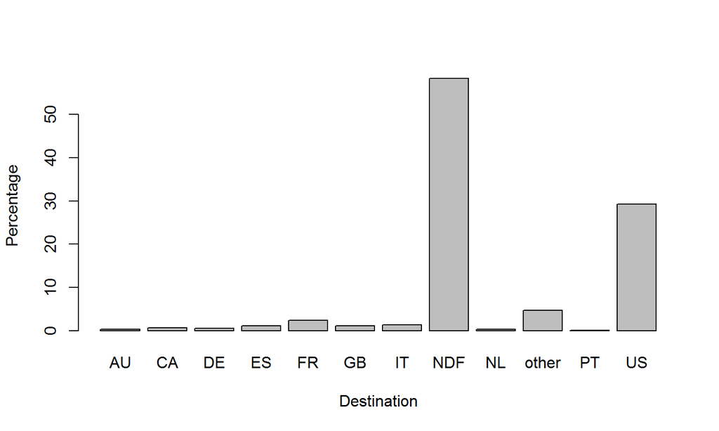

## Types of Booking

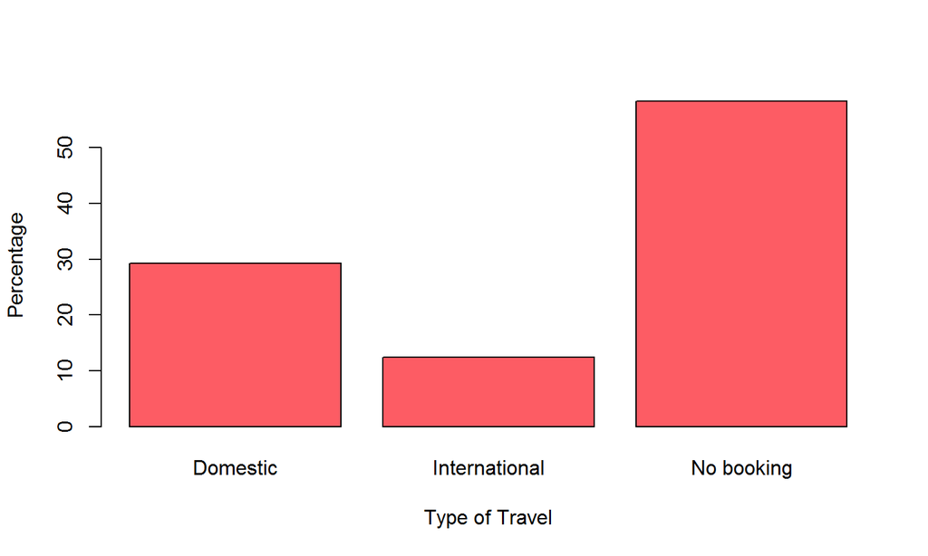

## Gender Data

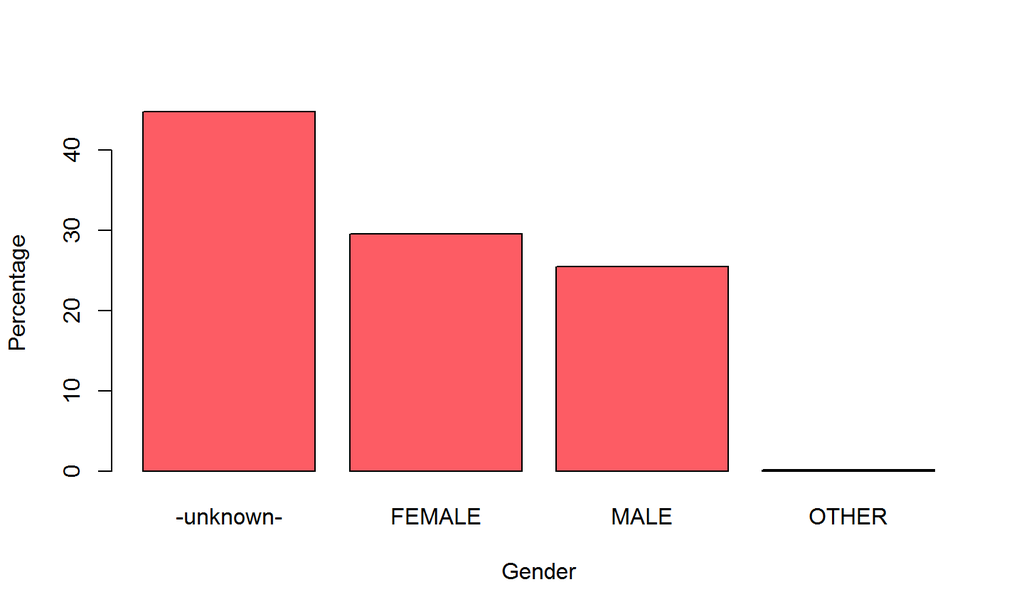

## Age Data

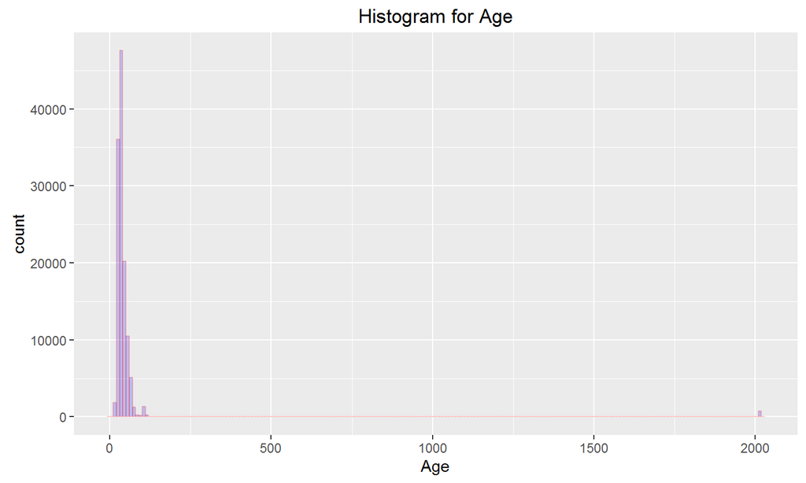

## Age Data - Post cleanup

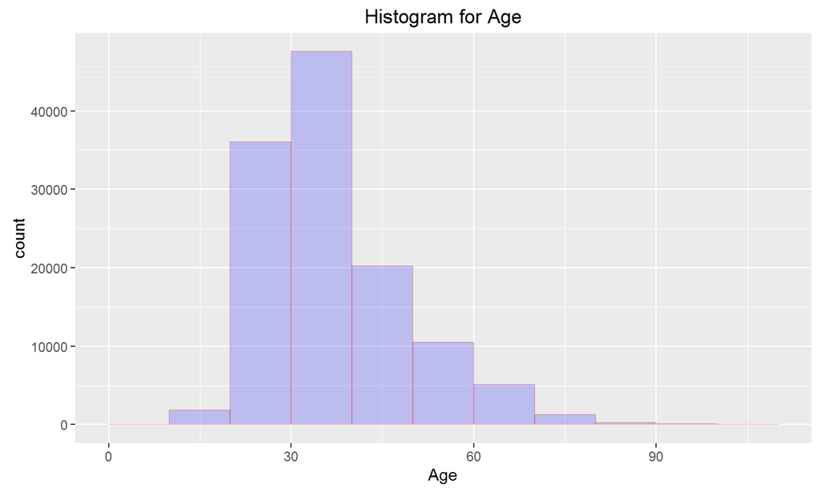

## User accounts and bookings over time

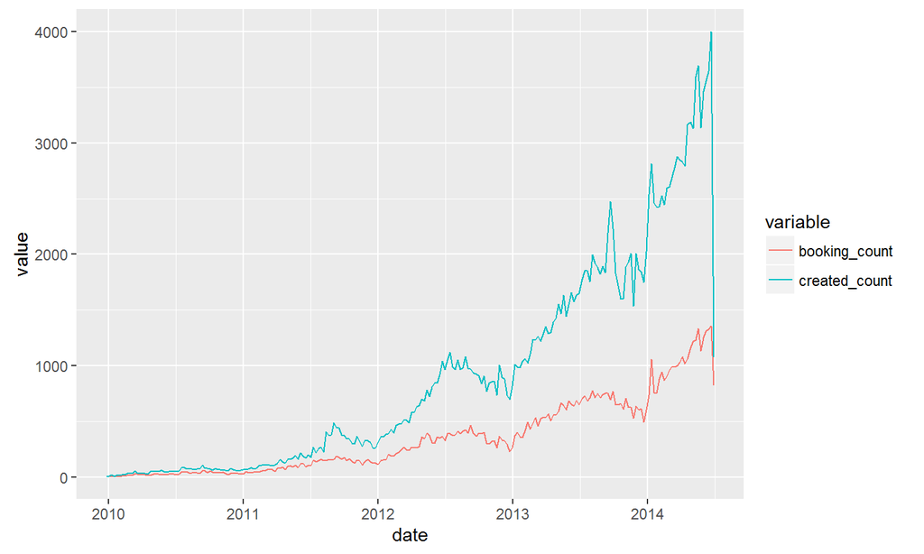

## Weekday corresponding to maximum booking

[figure not shown]

## Cleaning Data

- Cleaning up age variables
- Creating new variables such as ageProvded, difference of days in activity and booking
- Month of the booking
- Separating factors into their levels

## Predicting Successful Booking

Now we will try to break this problem into small parts. We will now try to predict whether a user books AirBnB or not.

```
##       actualBooking
## predDS     0     1
##      0 24860 10467
##      1 12503 16205
```

```
##
##  Pearson's Chi-squared test with Yates' continuity correction
##
## data:  confNBDS
## X-squared = 4686, df = 1, p-value < 2.2e-16
```

## Recursive Tree for Booking prediction

```
##            actualBooking
## PredictCART     0     1
##           0 30626 13205
##           1  6737 13467
```

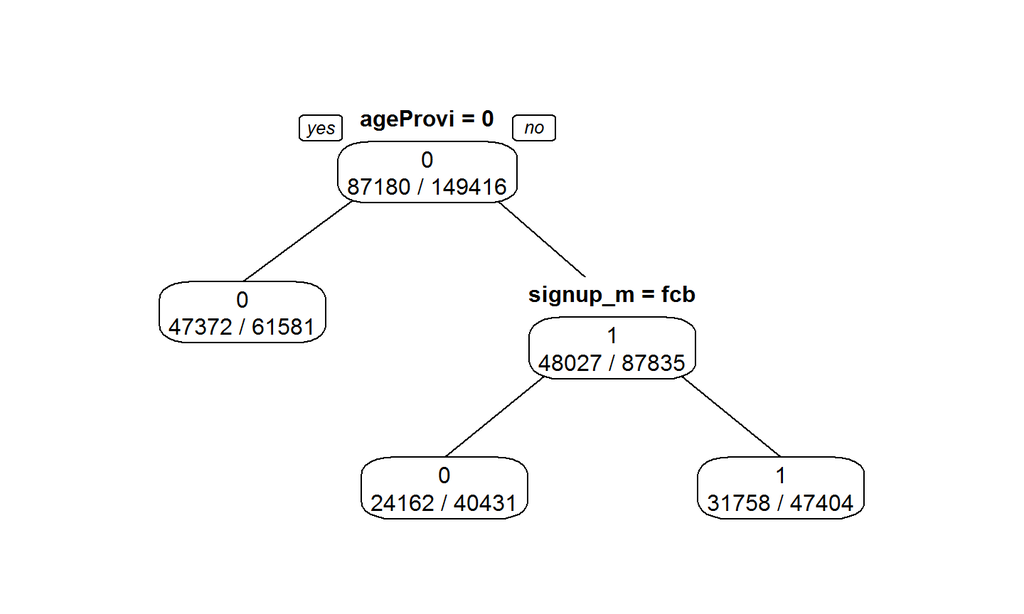

## Predicting type of Booking

```
##                bookingType
## predType        Domestic International
##   Domestic         17107          6966
##   International     1679           921
```

```
##
##  Pearson's Chi-squared test with Yates' continuity correction
##
## data:  confType
## X-squared = 47.091, df = 1, p-value = 6.777e-12
```

## Predicting Destination country

NaiveBayes

```
##         countries
## predCoun   AU   CA   DE   ES   FR   GB   IT   NL other   PT
##    AU      10    8    7    7   51   22   26    5   117    1
##    CA       4   30   24   39   76   27   51   11   134    3
##    DE       4   14   28   30   72   32   34    8    97    2
##    ES       9   21   21   40   95   41   61   11   147    3
##    FR      31   70   56  123  287  114  146   39   412   10
##    GB      15   22   11   44  103   42   59    8   178    6
##    IT       9   33   28   69  152   87   96   27   224   10
##    NL       6    9    5   15   28   10   19    6    45    0
##    other   74  217  134  300  624  317  350  110  1651   29
##    PT       0    4    4    8   19    5    9    4    23    1
```

## Predicting Destination country

```
##
##  Pearson's Chi-squared test
##
## data:  confCoun
## X-squared = 217.73, df = 81, p-value = 1.825e-14
```

```
## [1] 0.2752513
```

## Predicting Destination country

Now we sample 500 rows for each destination and check output.

```
##          countries
## predCoun1 AU CA DE ES FR GB IT NL other PT
##     AU    63 15 15  7  1  5  7 26     6 20
##     CA     4 21 18 12 10 16 16  9    16  1
##     DE    20 15 41 13  1 11  7 24     2  4
##     ES     2 14 15 15  6 23 24 10     9  6
##     FR     4 15 11 26 68 19 24  5    45  1
##     GB     6 21 16 21  3 26 19 10    14  1
##     IT     4 15 12 27 14 27 35  8    10  3
##     NL    32 17 10  5  2  8  1 43     3 10
##     other  3 16 10 24 44 13 16 10    45  3
##     PT    12  1  2  0  1  2  1  5     0 16
```

## Predicting Destination country

```
##
##  Pearson's Chi-squared test
##
## data:  confCoun1
## X-squared = 939.16, df = 81, p-value < 2.2e-16
```

```
## [1] 0.2636042
```

## Gradient Boosting

- eXtreme Gradient Boosing
- Produces a prediction model in the form of an ensemble of weak prediction models
- **Bagging**: Build models on random samples of data
- **Boosting**: More weight given to samples which are hard to classify rather than sample

xgb = xgboost(**data** = data.matrix(train_X), **label** = train_Y, **eta** = 0.1, **max_depth** = 9, **nround**=25, **subsample** = 0.5, **colsample_bytree** = 0.5, **seed** = 1, **eval_metric** = "merror", **objective** = "multi:softprob", **num_class** = 12, **nthread** = 3 )

## Important Parameters

- **Objective**: Type of model that needs to be trained. In our case we have used multi:softprob to do multi -class classification
- Output contains predicted probability of each data point belonging to each class
- **Depth**: Maximum Depth of trees(Default=6)
- **nround**: Number of passes on the data
- **nthread**: Number of cpu threads being used
- **eta**: Shrinks the feature weights after boosting to avoid overfitting
- **subsample**: Subsample Ratio to training instances

## Predicting Destination country

```
## [1] 64036
```

## Prediction Format

```
##      id P_country
## 1 48039       NDF
## 2 48039        US
## 3 48039     other
## 4 68504        US
## 5 68504     other
## 6 68504        FR
```

```
##     test_Y
## top1     0     1     2     3     4     5     6     7     8     9    10
##    0 37363     0     0     0     0     0     0     0     0     0     0
##    1     0 18713  3028  1507   428   697   675   851    65   229   318
##     test_Y
## top1    11
##    0     0
##    1   162
```

```
## [1] 0.8756949
```

## Does Signup_App have a relationship with Destination?

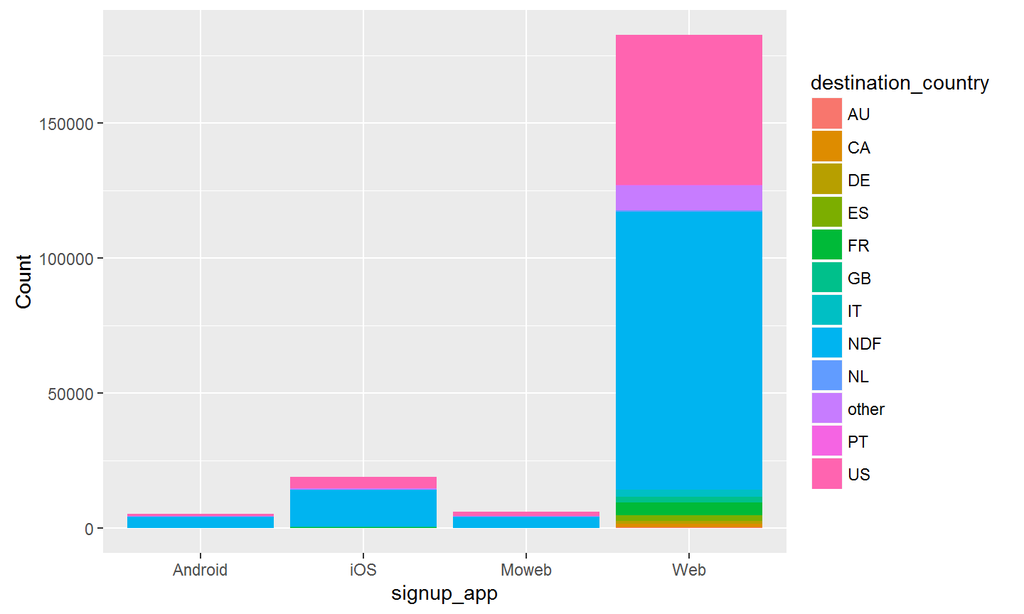

## Does Signup_App have a relationship with Destination?

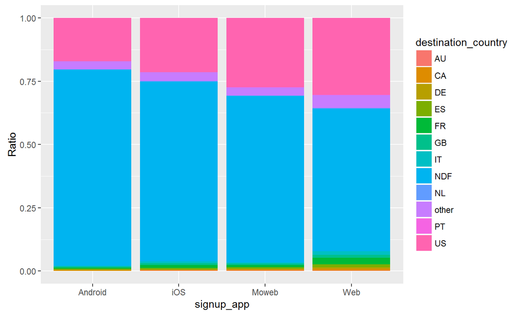

## What effect does Language have upon Destination Country?

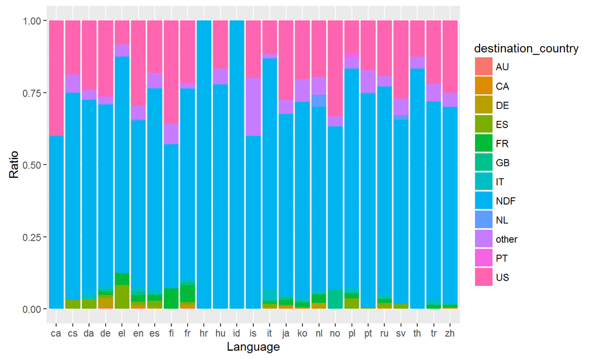

## What effect does Signup_method have upon Destination Country?

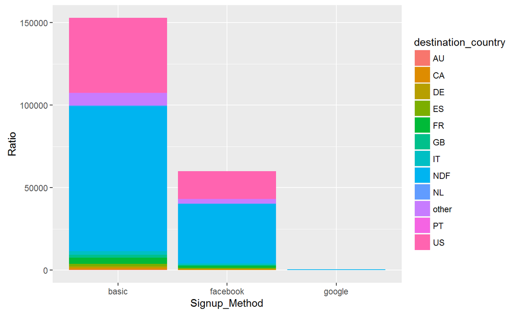

## What effect does Signup_method have upon Destination Country?

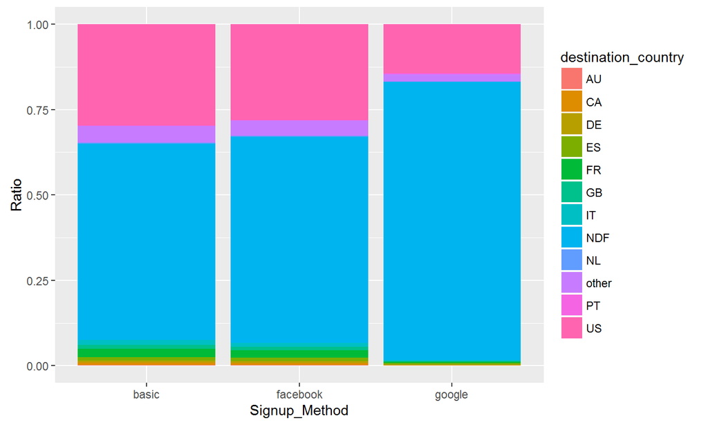

## Future scope for AirBnB

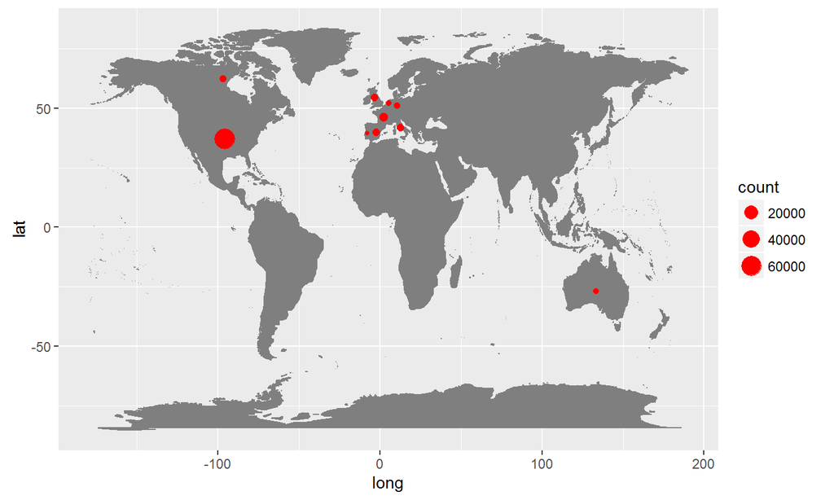

## What could be done better?

- Feature engineering
- Lots of scope for improving accuracy of NaiveBayes
- Implementing other prediction algorithms